# Trip Sequencing Part 4

Dave Hurst

Monday, February 16, 2015

Continuing the work to convert a trip into a sequence of segments. The input will be a full trip, and the output will be broken up into several components: - A list of segments with details (or reference to details) on each segment - A sequence of segment ID’s that comprise the trip - A of set data for each segment type

I’m going to try to reconstruct each trip out of segments made up of the following types:

- stops *DONE: See part 1* (no driver profile for these, but we need them to describe the segment)
- sharp turns *DONE: See part 2*
- curves (differentiated from sharp turns by radii (as a function of speed)) *DONE: See part 3*
- ~~bends ( differentiated from curves by time < 3 data points) ~~
- *straights*
- uncategorized:  
  – short straights (too short to collect profile info)  
  – slow rolling sections (drive thrus, driveways, etc. – no profile info)  
  – windy sections (ideally break these up later)  
  – other?

## Exploration

Same usual setup, same driver/trip 2591/49 Overlay curves (blue), sharp turns (magenta), stops (diamonds)

We’ll also use the ‘segment.parse.bearing’ function created in Segmentation 2 as a starting point. In order to get a little more juice from the bearing metric, I’ve set the speed threshold for bearing calculation to 2 seconds (v.thresh=2). Also I’ve adjusted the bearing “zone” to 4 (from 3 degrees in the Segmentation Part 2 doc).

```r
library(knitr)
```

```r
source("telematic_util.R")

data.dir <- "c:/NO_BACKUP/kaggle/telematics/drivers"

drivers.dir <- dir(data.dir)
set.seed(2349)

driver.id <- 2591
trip.id <- 49
trip <- getTrip( driver.id, trip.id, v.thresh=2 )

trip.seg <- segment.by.stops(trip)
trip.seg <- segment.by.turns( trip, trip.seg)
trip.seg <- segment.by.curve.gen( trip, trip.seg, r.thresh=300, t.thresh=4, ctype="curve")
trip.seg <- segment.by.curve.gen( trip, trip.seg, t.thresh=3, zone=4, ctype="straight")

segs <- trip.seg[!grepl("^x", trip.seg$type), ]
segs <- segs[ order(segs$t0),]
curves <- segs[grepl("curve",segs$type), ]
straights <- segs[grepl("straight",segs$type), ]
turns <- segs[grepl("turn",segs$type), ]
stops <- segs[grepl("stop",segs$type), ]
```

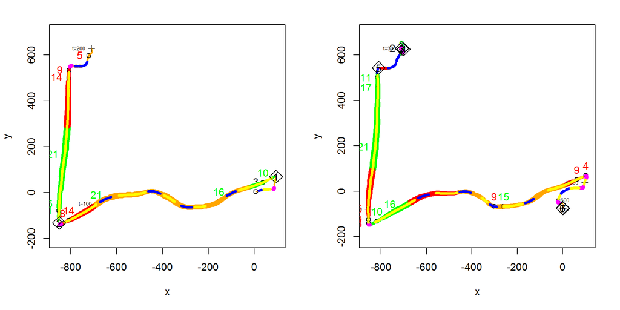

```r
# ss <- segment.parse.bearing(trip, tlen.min=3, zone=4)
# ss$tn <- ss$t0 + ss$tlen

   par.orig <- par(mfrow=c(1,2))
plotTrip       (trip,         tmax=200, header=F)
plotTripOverlay(trip, curves, tmax=200)
plotTripOverlay(trip, turns, tmax=200, lwd=6, col="magenta")
plotTripOverlay(trip, straights, tmax=200, col="yellow")
# plotTripOverlay(trip, ss, tmax=200, col="yellow")
plotTrip.stopOverlay(trip, stops, tmax=200)

plotTrip       (trip,         tmin=200, header=F)
plotTripOverlay(trip, curves, tmin=200)
plotTripOverlay(trip, turns, tmin=200, lwd=6, col="magenta")
plotTripOverlay(trip, straights, tmin=200, col="yellow")
# plotTripOverlay(trip, ss, tmin=200, col="yellow")
plotTrip.stopOverlay(trip, stops, tmin=200)
```

```r
   par(par.orig)
```

Here are some stats on the trip segmentation:

```r
segment.summary <- function ( segs , trip ) {
    segs$tlen <- segs$tn - segs$t0 + 1
    unk.segs <- is.na( segs$type)
    segs[unk.segs, "type"] <- "uncategorized"
    stats <- data.frame(table(segs$type))
    tlen.sum <- aggregate( segs$tlen, list(segs$type), sum )
    stats <- cbind( stats, tlen.sum$x, round(tlen.sum$x/nrow(trip)*100, 2))
    colnames(stats) <- c("Type", "count", "total_t", "pct_of_trip")
    loss <- nrow(trip) - sum( stats[,"total_t"])
    stats <- rbind(stats, data.frame(Type="loss", count=NA, total_t= loss, pct_of_trip= round(100*loss/nrow(trip), 2 )))
    stats
}
segment.summary( segs, trip)
```

```
##            Type count total_t pct_of_trip
## 1         curve    15      74       12.09
## 2          stop     7     204       33.33
## 3      straight    17     198       32.35
## 4          turn    10      35        5.72
## 5 uncategorized    20      82       13.40
## 6          loss    NA      19        3.10
```

And again for trip 99

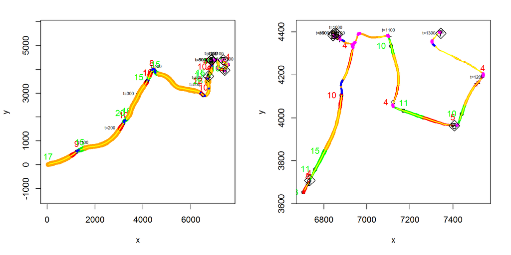

```r
driver.id <- 2591
trip.id <- 99
trip <- getTrip( driver.id, trip.id, v.thresh=2 )
trip.seg <- segment.by.stops(trip)
trip.seg <- segment.by.turns( trip, trip.seg)
trip.seg <- segment.by.curve.gen( trip, trip.seg, r.thresh=300, t.thresh=4, ctype="curve")
trip.seg <- segment.by.curve.gen( trip, trip.seg, t.thresh=3, zone=4, ctype="straight")

segs <- trip.seg[!grepl("^x", trip.seg$type), ]
segs <- segs[ order(segs$t0),]
curves <- segs[grepl("curve",segs$type), ]
straights <- segs[grepl("straight",segs$type), ]
turns <- segs[grepl("turn",segs$type), ]
stops <- segs[grepl("stop",segs$type), ]

  par(mfrow=c(1,2))
plotTrip       (trip,          header=F)
plotTripOverlay(trip, curves)
plotTripOverlay(trip, turns, lwd=6, col="magenta")
plotTripOverlay(trip, straights, lwd=2, col="yellow")
plotTrip.stopOverlay(trip, stops)


plotTrip       (trip, tmin=600,         header=F)
plotTripOverlay(trip, tmin=600, curves)
plotTripOverlay(trip, tmin=600, turns, lwd=6, col="magenta")
plotTripOverlay(trip, straights, tmin=600, lwd=2, col="yellow")
plotTrip.stopOverlay(trip, stops)
```

```r
  par( par.orig )

segment.summary( segs, trip)
```

```
##            Type count total_t pct_of_trip
## 1         curve    18      97        7.08
## 2          stop     7     412       30.07
## 3      straight    20     694       50.66
## 4          turn    13      40        2.92
## 5 uncategorized    25     109        7.96
## 6          loss    NA      18        1.31
```